# index

**Table of contents**

- Sweet Lift Taxi
  - Import Libraries
  - EDA
  - Model Preparation
  - Modeling
    - Linear Regression
    - Decision Tree
    - Random Forest
    - Ada Boost
    - Gradient Boosting
    - XG boost
    - Light GBM
    - Catboost
    - Voting Regressor
  - Comparing Model Scores
  - Final Model
    - Overall Conclusions

# Sweet Lift Taxi

Sweet Lift Taxi company has collected data on taxi orders at airports. Their aim is to predict the amount of taxi orders for the next hour, in order to allocate more drivers for peak hours. We will build a model with an RMSE lower than 48.

```python
#!pip install --user plotly_express
```

## Import Libraries

```python
# Import libraries
import pandas as pd
import numpy as np
import plotly_express as px
from matplotlib import pyplot as plt
from statsmodels.tsa.seasonal import seasonal_decompose
from sklearn.linear_model import LinearRegression
from sklearn.tree import DecisionTreeRegressor
from sklearn.ensemble import AdaBoostRegressor, GradientBoostingRegressor, VotingRegressor, RandomForestRegressor
from sklearn.model_selection import train_test_split
from sklearn.metrics import mean_squared_error as mse, mean_absolute_error as mae, make_scorer
from xgboost import XGBRegressor
from lightgbm import LGBMRegressor
import lightgbm as lgb
from catboost import CatBoostRegressor, Pool
```

```python
# read dataframe
df = pd.read_csv('datasets/taxi.csv', parse_dates=['datetime'], index_col=['datetime'])
```

```python
# sorting index
df.sort_index(inplace=True)
```

```python
# checking if index is monotonic
print(df.index.is_monotonic)
```

```
True
```

```python
# look at dataframe
df.head()
```

| datetime | num_orders |
| --- | --- |
| 2018-03-01 00:00:00 | 9 |
| 2018-03-01 00:10:00 | 14 |
| 2018-03-01 00:20:00 | 28 |
| 2018-03-01 00:30:00 | 20 |
| 2018-03-01 00:40:00 | 32 |

```python
# info on num orders columns
df.info()
```

```
<class 'pandas.core.frame.DataFrame'>
DatetimeIndex: 26496 entries, 2018-03-01 00:00:00 to 2018-08-31 23:50:00
Data columns (total 1 columns):
 #   Column      Non-Null Count  Dtype
---  ------      --------------  -----
 0   num_orders  26496 non-null  int64
dtypes: int64(1)
memory usage: 414.0 KB
```

```python
# confirming no missing values
df.isna().sum()
```

```
num_orders    0
dtype: int64
```

```python
# resample data by the hour
df = df.resample('1H').sum()
```

We loaded the data and then converted the dates into datetime format. We then made the datetime column our index, and sorted the index. We checked to make sure the data was free of missing values. Following that, we resampled the data by the hour.

## EDA

```python
# summary statistics on the number of orders
df.describe()
```

|  | num_orders |
| --- | --- |
| count | 4416.000000 |
| mean | 84.422781 |
| std | 45.023853 |
| min | 0.000000 |
| 25% | 54.000000 |
| 50% | 78.000000 |
| 75% | 107.000000 |
| max | 462.000000 |

```python
# hourly number of orders
fig = px.line(df.num_orders, title='Total Hourly Number of Orders', template='ggplot2', height=600, labels={'value': 'Number of Orders'})
fig.update_xaxes(rangeslider_visible=True,
    rangeselector=dict(
        buttons=list([
            dict(count=1, label='1m', step='month', stepmode='backward'),
            dict(count=6, label='6m', step='month', stepmode='backward')
            ])
        )
    )
fig.show()
```

[interactive chart not shown]

This is a visual of the timeseries data sampled on the hour. The y axis shows the number of taxi orders.

```python
# distribution of orders
px.box(df.num_orders, title='Distribution of Orders', template='ggplot2', labels={'variable': 'Orders', 'value': 'count'}, height=600)
```

[interactive chart not shown]

```python
# Average daily orders
numbers = [6, 12, 24, 168, 720]
for i in numbers:
    px.line(df.num_orders.rolling(i).mean(), title=f'Mean Number of Orders per {i} Hours', template='ggplot2', labels={'value': 'Number of Orders', 'datetime':'Dates'}, height=600).show()
```

[interactive chart not shown]

These visuals show the number of orders resampled for 6 hours, 12 hours, per day, per week, and per month. These visualizations allow us the clearly see the trend in orders increase gradually from April to August.

```python
# decomposed dataset
decomposed = seasonal_decompose(df)
```

```python
# decomposed trend
px.line(decomposed.trend, title='Trend', template='ggplot2')
```

[interactive chart not shown]

```python
# decomposed seasonality
px.line(decomposed.seasonal, title='Seasonality', template='ggplot2')
```

[interactive chart not shown]

```python
# decomposed residual
px.line(decomposed.resid, title='Residual', template='ggplot2')
```

[interactive chart not shown]

These visualizations show us the decomposed trends of the data. The trend is the same chart as the resampled daily chart. We see the seasonality chart is tight, which may be due to the short window of time given by the data. The residuals generally fluctuate around 0, but starts to show outliers in August.

```python
# difference in number of orders
fig = px.line(df.num_orders-df.num_orders.shift(), title='Difference in Number of Orders', template='ggplot2', height=700)
fig.update_xaxes(rangeslider_visible=True,
    rangeselector=dict(
        buttons=list([
            dict(count=1, label='1m', step='month', stepmode='backward'),
            dict(count=6, label='6m', step='month', stepmode='backward')
            ])
        )
    )
fig.show()
```

[interactive chart not shown]

Looking at the shifted difference in the number of orders, we see the values increase as time increases. These differences become more pronounced from August onward.

## Model Preparation

```python
# Making features, max lag 24 and rolling mean 24
def make_features(data, max_lag, rolling_mean_size):
    data['year'] = data.index.year
    data['month'] = data.index.month
    data['day'] = data.index.day
    data['dayofweek'] = data.index.dayofweek
    data['hour'] = data.index.hour

    for lag in range(1, max_lag + 1):
        data['lag_{}'.format(lag)] = data['num_orders'].shift(lag)

    data['rolling_mean'] = (
        data['num_orders'].shift().rolling(rolling_mean_size).mean()
    )


make_features(df, 24, 24)
```

```python
# splitting dataset to train, valid, and test
train, test = train_test_split(df, shuffle=False, test_size=0.1, random_state=19)
train, valid = train_test_split(train, shuffle=False, test_size=0.11, random_state=19)

print('Train Dataset = ', ' Start : ', train.index.min(), '   End : ', train.index.max(), '   Difference : ', abs(train.index.min() - train.index.max()))
print('Valid Dataset = ', ' Start : ', valid.index.min(), '   End : ', valid.index.max(), '   Difference : ', abs(valid.index.min() - valid.index.max()))
print('Test Dataset = ', ' Start : ', test.index.min(),  '   End : ', test.index.max(), '   Difference : ', abs(test.index.min() - test.index.max()))
```

```
Train Dataset =   Start :  2018-03-01 00:00:00    End :  2018-07-26 07:00:00    Difference :  147 days 07:00:00
Valid Dataset =   Start :  2018-07-26 08:00:00    End :  2018-08-13 13:00:00    Difference :  18 days 05:00:00
Test Dataset =   Start :  2018-08-13 14:00:00    End :  2018-08-31 23:00:00    Difference :  18 days 09:00:00
```

```python
# Dropping missing values from datasets
train = train.dropna()
valid = valid.dropna()
test = test.dropna()
```

```python
# Splitting target and features
X_train = train.drop(columns='num_orders')
y_train = train.num_orders

X_valid = valid.drop(columns='num_orders')
y_valid = valid.num_orders

X_test = test.drop(columns='num_orders')
y_test = test.num_orders
```

```python
features = df.drop(columns='num_orders')
target = df.num_orders
```

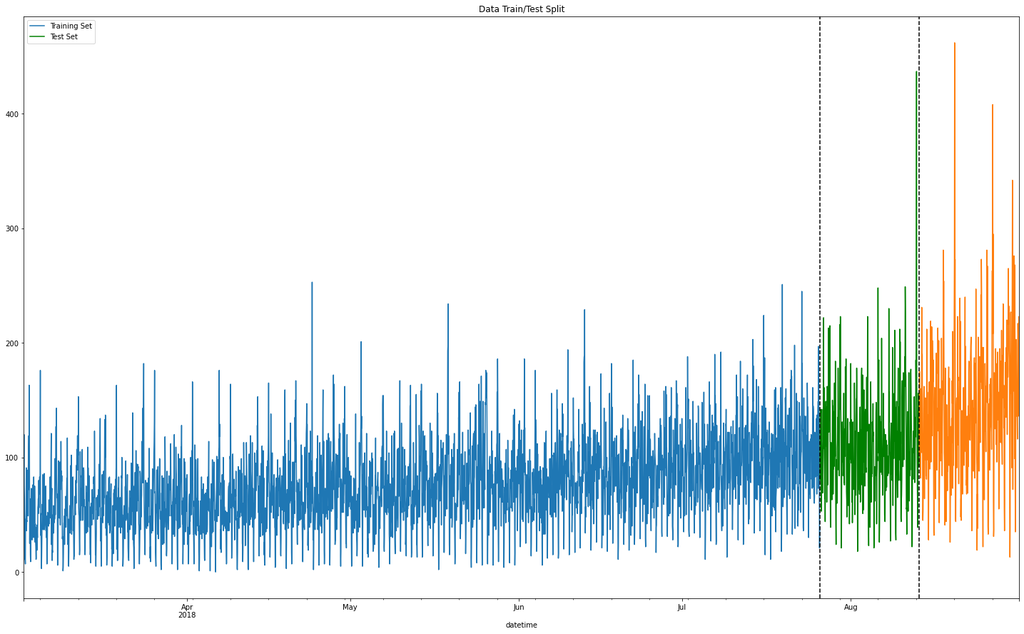

```python
# visual of train test split
fig, ax = plt.subplots(figsize=(25,15))
train.num_orders.plot(ax=ax, label='Training Set', title='Data Train/Test Split')
valid.num_orders.plot(ax=ax, label='Valid Set', color='green')
test.num_orders.plot(ax=ax, label='Test Set')
ax.axvline('2018-07-26 08:00:00', color='black', ls='--')
ax.axvline('2018-08-13 14:00:00', color='black', ls='--')
ax.legend(['Training Set', 'Test Set'])
plt.show()
```

We define a function to make features, with a max lag of 24 and a rolling mean of 24. We then split the data into three parts: train, valid, and test. We will train the models with the training data, then tune the models with the validation set. The test set is reserved for evaluating the performance of the final model we choose. Since it is crucial to have adequate training data, we limited the validation and test sets to 10% of the data each. This leaves roughly 80% of the data for training. Furthermore, with time series, we can not randomly select points in our data to split, so shuffle was set to false. This gives us the correct sequence in the order of the different sets, made evident by the last figure.

## Modeling

### Linear Regression

```python
# linear regression
lr = LinearRegression() # initialize model constructor
lr.fit(X_train, y_train) # train model on training set

predictions_valid_lr = lr.predict(X_valid) # get model predictions on validation set

result = mse(y_valid, predictions_valid_lr) ** 0.5 # calculate RMSE on validation set
print("RMSE of the linear regression model on the validation set:", result)
```

```
RMSE of the linear regression model on the validation set: 34.282142440117
```

```python
# Get the feature importances of the best model
lr_importances = lr.coef_

# Create a dataframe with the feature importances and the corresponding feature names
lr_importances_df = pd.DataFrame({'feature':X_train.columns, 'coefficients':lr.coef_})

# Sort the dataframe by importance
lr_importances_df.sort_values(by='coefficients', ascending=False, inplace=True)
```

[output not shown]

The rolling mean is the coefficient with the highest value among the linear regression features. We achieve an RMSE score of 34.28 with the validation set.

### Decision Tree

```python
# Decision Tree
best_model = None
best_result = 50
best_depth = 0
for depth in range(1, 6): # choose hyperparameter range
    dtr = DecisionTreeRegressor(random_state=19, max_depth=depth)
    dtr.fit(X_train, y_train) # train model on training set
    predictions_valid_dtr = dtr.predict(X_valid) # get model predictions on validation set
    result = mse(y_valid, predictions_valid_dtr) ** 0.5
    if result < best_result:
        best_model = dtr
        best_result = result
        best_depth = depth

print(f"RMSE of the best model on the validation set (max_depth = {best_depth}): {best_result}")
```

```
RMSE of the best model on the validation set (max_depth = 5): 38.54337041017864
```

```python
# Get the feature importances of the best model
dtr_importances = dtr.feature_importances_

# Create a dataframe with the feature importances and the corresponding feature names
dtr_importances_df = pd.DataFrame({'feature':X_train.columns, 'importance':dtr.feature_importances_})

# Sort the dataframe by importance
dtr_importances_df.sort_values(by='importance', ascending=False, inplace=True)
```

```python
# top 10 feature importances
px.pie(dtr_importances_df.head(10), names='feature', values='importance', title='Top 10 Feature Importance for Decision Tree Regression', template='ggplot2', hole=0.2)
```

[interactive chart not shown]

The lag 24 feature is the most important in the decesion tree regression. We achieve an RMSE score of 38.54 with the validation set.

### Random Forest

```python
# Random Forest
best_model = None
best_result = 50
best_est = 0
best_depth = 0
for est in range(600, 601):
    for depth in range (100, 101):
        rf = RandomForestRegressor(random_state=19, n_estimators=est, max_depth=depth)
        rf.fit(X_train, y_train) # train model on training set
        predictions_valid = rf.predict(X_valid) # get model predictions on validation set
        result = mse(y_valid, predictions_valid) ** 0.5 # calculate RMSE on validation set
        if result < best_result:
            best_model = rf
            best_result = result
            best_est = est
            best_depth = depth

print("RMSE of the best model on the validation set:", best_result, "n_estimators:", best_est, "best_depth:", depth)
```

```
RMSE of the best model on the validation set: 32.013650992753774 n_estimators: 600 best_depth: 100
```

```python
# Get the feature importances of the best model
rf_importances = best_model.feature_importances_

# Create a dataframe with the feature importances and the corresponding feature names
rf_importances_df = pd.DataFrame({'feature':X_train.columns, 'importance':rf.feature_importances_})

# Sort the dataframe by importance
rf_importances_df.sort_values(by='importance', ascending=False, inplace=True)
```

```python
# top 10 feature importances
px.pie(rf_importances_df.head(10), names='feature', values='importance', title='Top 10 Feature Importance for Random Forest Regression', template='ggplot2', hole=0.2)
```

[interactive chart not shown]

The Lag 24 feature has the greatest importance in the random forest model. The RMSE score is 32.01.

### Ada Boost

```python
# ADA Boost
regr = AdaBoostRegressor(random_state=19, n_estimators=100)
regr.fit(X_train, y_train)

predictions_valid_regr = regr.predict(X_valid) # get model predictions on validation set

result = mse(y_valid, predictions_valid_regr) ** 0.5 # calculate RMSE on validation set
print("RMSE of the ada boost regression model on the validation set:", result)
```

```
RMSE of the ada boost regression model on the validation set: 34.89293536381952
```

```python
# table of feature importance
regr_imp = [t for t in zip(features, regr.feature_importances_)]
regr_imp_df = pd.DataFrame(regr_imp, columns=['feature', 'varimp'])
regr_imp_df = regr_imp_df.sort_values('varimp', ascending=False)
```

```python
# top 10 feature importances
px.pie(regr_imp_df.head(10), names='feature', values='varimp', title='Top 10 Feature Importance for Ada Boost Regresion', hole=.2, template='ggplot2')
```

[interactive chart not shown]

The lag 24 feature is the most important, followed by the lag 1, among the Ada Boost model. The RMSE score is 34.89.

### Gradient Boosting

```python
# Gradient Boost
gbr = GradientBoostingRegressor(random_state=19, learning_rate=0.2, n_estimators=1000, verbose=1, max_depth=3)
gbr.fit(X_train, y_train)

predictions_valid_gbr = gbr.predict(X_valid)

result = mse(y_valid, predictions_valid_gbr) ** 0.5 # calculate RMSE on validation set
print("RMSE of the gradient boosting model on the validation set:", result)
```

```
      Iter       Train Loss   Remaining Time
         1        1055.7262           12.97s
         2         902.6644           12.95s
         3         800.7340           12.60s
         4         723.8976           12.17s
         5         664.3207           12.11s
         6         624.8460           10.34s
         7         593.0704           11.08s
         8         561.8075           11.62s
         9         540.4896           10.32s
        10         523.9846           10.82s
        20         433.9193           11.69s
        30         394.4030           11.05s
        40         367.8561           11.23s
        50         347.6763           10.76s
        60         327.1108           10.92s
        70         313.1352           10.75s
        80         299.1902           10.64s
        90         284.5592           10.63s
       100         273.5208           10.51s
       200         186.1205            9.35s
       300         136.8925            8.21s
       400         102.2159            6.98s
       500          79.6783            5.77s
       600          61.4060            4.64s
       700          46.4215            3.47s
       800          36.8524            2.31s
       900          29.6124            1.16s
      1000          23.1917            0.00s
RMSE of the gradient boosting model on the validation set: 35.11544177065954
```

```python
# table of feature importance
gbr_imp = [t for t in zip(features, gbr.feature_importances_)]
gbr_imp_df = pd.DataFrame(gbr_imp, columns=['feature', 'varimp'])
gbr_imp_df = gbr_imp_df.sort_values('varimp', ascending=False)
```

```python
# top 10 feature importances
px.pie(gbr_imp_df.head(10), names='feature', values='varimp', title='Top 10 Feature Importance for Gradient Boosting', hole=.2, template='ggplot2')
```

[interactive chart not shown]

The lag 24 feature is the most important, followed by the lag 1, among the Gradient Boost model. The RMSE score is 35.12.

### XG boost

```python
# XGB
xgbr = XGBRegressor(learning_rate=0.09, n_estimators=800, eval_metric='rmse', random_state=19, max_depth=6, early_stopping_rounds=500)

xgbr.fit(X_train, y_train, eval_set=[(X_train, y_train), (X_valid, y_valid)], verbose=200)

# Make predictions on the test set
predictions_xgbr = xgbr.predict(X_valid)

result = mse(y_valid, predictions_xgbr) ** 0.5 # calculate RMSE on validation set
print()
print("RMSE of the xgbm model on the validation set:", result)
```

```
RMSE of the xgbm model on the validation set: 31.691194462756986
```

```python
# table of feature importance
xgbr_imp = [t for t in zip(features, xgbr.feature_importances_)]
xgbr_imp_df = pd.DataFrame(xgbr_imp, columns=['feature', 'varimp'])
xgbr_imp_df = xgbr_imp_df.sort_values('varimp', ascending=False)
```

```python
# top 10 feature importances
px.pie(xgbr_imp_df.head(10), names='feature', values='varimp', title='Top 10 Feature Importance for XG Boost', hole=.2, template='ggplot2')
```

[interactive chart not shown]

The lag 24 feature is the most important, followed by the lag 1, among the XG Boost model. The RMSE score is 31.69.

### Light GBM

```python
# LGBM

# Create a LightGBM dataset
lgb_train = lgb.Dataset(X_train, y_train, params={'verbose': -1}, free_raw_data=False)
lgb_valid = lgb.Dataset(X_valid, y_valid, reference=lgb_train, params={'verbose': -1}, free_raw_data=False)

# Define the parameters for the LightGBM model
params = {
    'objective': 'regression',
    'metric': 'root_mean_squared_error',
    'boosting_type': 'gbdt',
    'random_state': 19,
    'verbose': -1
}

# Train the LightGBM model
lgbm = lgb.train(params, lgb_train, valid_sets=lgb_valid, num_boost_round=100, early_stopping_rounds=50, verbose_eval=False)

# Make predictions on the test set
predictions_valid_lgbm = lgbm.predict(X_valid)

result = mse(y_valid, predictions_valid_lgbm) ** 0.5 # calculate RMSE on validation set
print()
print("RMSE of the lgbm model on the validation set:", result)
```

```
RMSE of the lgbm model on the validation set: 31.5105670958812
```

```python
# Get the feature importances of the trained model
lgbm_importances = lgbm.feature_importance()

# Create a dataframe with the feature importances and the corresponding feature names
lgbm_importances_df = pd.DataFrame({'feature':X_train.columns, 'importance':lgbm_importances})

# Sort the dataframe by importance
lgbm_importances_df.sort_values(by='importance', ascending=False, inplace=True)
```

```python
# top 10 feature importances
px.pie(lgbm_importances_df.head(10), names='feature', values='importance', title='Top 10 Feature Importance for Light GBM Regression', hole=.2, template='ggplot2')
```

[interactive chart not shown]

The lag 24 feature is the most important, followed by the lag 1, 3, and 17, among the light GB model. The RMSE score is 31.51.

### Catboost

```python
# catboost

catb = CatBoostRegressor(task_type='GPU', loss_function='RMSE', eval_metric='RMSE', iterations=2000, random_seed=19, early_stopping_rounds=500)

catb.fit(X_train, y_train, eval_set=(X_valid, y_valid), verbose=100, use_best_model=True)

# Make predictions on the test set
predictions_valid_catb = catb.predict(X_valid)

result = mse(y_valid, predictions_valid_catb) ** 0.5 # calculate RMSE on validation set
print()
print("Catboost model on the test set: ")
catb.best_score_
```

```
Learning rate set to 0.058377
0:	learn: 34.6860472	test: 56.9806604	best: 56.9806604 (0)	total: 35.5ms	remaining: 1m 10s
100:	learn: 19.2988741	test: 33.0876620	best: 33.0876620 (100)	total: 3.39s	remaining: 1m 3s
200:	learn: 17.3837171	test: 31.5593320	best: 31.5274555 (196)	total: 5.9s	remaining: 52.8s
300:	learn: 16.1068747	test: 31.1158582	best: 31.0932530 (292)	total: 8.34s	remaining: 47.1s
400:	learn: 15.1570285	test: 30.9089598	best: 30.8874333 (355)	total: 11.5s	remaining: 45.7s
500:	learn: 14.4524653	test: 30.6655332	best: 30.6543250 (489)	total: 14.5s	remaining: 43.4s
600:	learn: 13.8817461	test: 30.6080922	best: 30.5862454 (598)	total: 17.2s	remaining: 40s
700:	learn: 13.4356620	test: 30.7307059	best: 30.5862454 (598)	total: 20.1s	remaining: 37.2s
800:	learn: 12.9640404	test: 30.6683495	best: 30.5862454 (598)	total: 22.5s	remaining: 33.7s
900:	learn: 12.4940995	test: 30.5313766	best: 30.5306439 (899)	total: 25.2s	remaining: 30.7s
1000:	learn: 12.2133156	test: 30.4880769	best: 30.4758529 (984)	total: 27.7s	remaining: 27.7s
1100:	learn: 11.8778875	test: 30.4403165	best: 30.4204461 (1074)	total: 30.1s	remaining: 24.6s
1200:	learn: 11.5985256	test: 30.4944333	best: 30.4204461 (1074)	total: 32.7s	remaining: 21.8s
1300:	learn: 11.3403935	test: 30.4790097	best: 30.4204461 (1074)	total: 35.2s	remaining: 18.9s
1400:	learn: 11.0560481	test: 30.5092421	best: 30.4204461 (1074)	total: 37.7s	remaining: 16.1s
1500:	learn: 10.8126411	test: 30.5841319	best: 30.4204461 (1074)	total: 40.1s	remaining: 13.3s
bestTest = 30.42044607
bestIteration = 1074
Shrink model to first 1075 iterations.

Catboost model on the test set:
```

```
{'learn': {'RMSE': 10.689158761762712},
 'validation': {'RMSE': 30.420446065315765}}
```

```python
# Get the feature importances of the trained model
catb_importances = catb.feature_importances_

# Create a dataframe with the feature importances and the corresponding feature names
catb_importances_df = pd.DataFrame({'feature':X_train.columns, 'importance':catb_importances})

# Sort the dataframe by importance
catb_importances_df.sort_values(by='importance', ascending=False, inplace=True)
```

```python
# top 10 feature importances
px.pie(catb_importances_df.head(10), names='feature', values='importance', title='Top 10 Feature Importance for Catboost Regression', hole=.2, template='ggplot2')
```

[interactive chart not shown]

The lag 24 feature is the most important, followed by the lag 1, among the catboost model. The RMSE score is 30.42.

### Voting Regressor

```python
# Training classifiers
# reg1 = RandomForestRegressor(random_state=12345, n_estimators=90, max_depth=100)
# reg2 = GradientBoostingRegressor(random_state=19, learning_rate=0.2, n_estimators=1000, verbose=1, max_depth=3)
reg3 = XGBRegressor(learning_rate=0.09, n_estimators=800, eval_metric='rmse', random_state=19, max_depth=6) #, early_stopping_rounds=500)
reg4 = lgb.LGBMRegressor(objective='regression', metric='root_mean_squared_error', boosting_type='gbdt', random_state=19) #, early_stopping_rounds=50)
reg5 = CatBoostRegressor(task_type='GPU', loss_function='RMSE', eval_metric='RMSE', iterations=2000, random_seed=19) #, early_stopping_rounds=500)

ereg = VotingRegressor(estimators=[#('rf', reg1),
                                #('gbr', reg2),
                                ('xgb', reg3),
                                ('lgb', reg4),
                                ('cat', reg5)]

                               )
ereg = ereg.fit(X_train, y_train)

# Make predictions on the test set
predictions_valid_ereg = ereg.predict(X_valid)

result = mse(y_valid, predictions_valid_ereg) ** 0.5 # calculate RMSE on validation set
print()
print("voting regressor model on the valid set: ", result)
```

[output not shown]

[output cut: 1948 more lines]

[output not shown]

## Comparing Model Scores

```python
# making model scores dataframe
model_scores = pd.DataFrame({'Linear Regression': 34.28, 'Decision Tree': 38.54, 'Random Forest': 32.01, 'Ada Boost': 34.89, 'Gradient Boost': 35.11, 'XG Boost': 31.69, 'Light GBM': 31.51,
             'Catboost': 30.42, 'Voting Regressor': 30.78}, index={'RMSE'})
model_scores = model_scores.T
```

```python
# Model RMSE scores
px.scatter(model_scores, title='Model RMSE Scores', template='ggplot2', color=model_scores.index, size='RMSE', y='RMSE', size_max=30, labels={'index': 'Model'})
```

[interactive chart not shown]

## Final Model

```python
# combine validation set with training set
X_full = pd.concat([X_train, X_valid])
y_full = pd.concat([y_train, y_valid])
```

```python
# Training classifiers
# reg1 = RandomForestRegressor(random_state=12345, n_estimators=90, max_depth=100)
# reg2 = GradientBoostingRegressor(random_state=19, learning_rate=0.2, n_estimators=1000, verbose=1, max_depth=3)
reg3 = XGBRegressor(learning_rate=0.09, n_estimators=800, eval_metric='rmse', random_state=19, max_depth=6) #, early_stopping_rounds=500)
reg4 = lgb.LGBMRegressor(objective='regression', metric='root_mean_squared_error', boosting_type='gbdt', random_state=19) #, early_stopping_rounds=50)
reg5 = CatBoostRegressor(task_type='GPU', loss_function='RMSE', eval_metric='RMSE', iterations=2000, random_seed=19) #, early_stopping_rounds=500)

final = VotingRegressor(estimators=[#('rf', reg1),
                                #('gbr', reg2),
                                ('xgb', reg3),
                                ('lgb', reg4),
                                ('cat', reg5)],
                                verbose=-1
                                )
final = final.fit(X_full, y_full)

# Make predictions on the test set
final_predictions = final.predict(X_test)

result = mse(y_test, final_predictions) ** 0.5 # calculate RMSE on validation set
print()
print("voting regressor model on the test set: ", result)
```

[output not shown]

[output cut: 1952 more lines]

[output not shown]

The final model we chose was the voting regressor. We achieved a RMSE score of 41.24 with the test set. This model performs better than the required RMSE score of 48. Therefore, we have accurately predicted the future number of orders.